# **PRÁTICA ESTATÍSTICA II**

Base Nutrição — Análise Exploratória e Inferencial

Universidade Federal Fluminense

12/05/2026

# **SUMÁRIO**

1. Contextualização
2. Base de Dados
3. Estatística Descritiva
4. Análises Inferenciais
5. Correlação
6. Conclusões

# **1. Contextualização**

## **Pandemia, objetivos e hipóteses**

A pandemia da COVID-19 provocou mudanças relevantes:

- hábitos alimentares;
- prática de atividade física;
- comportamento social;
- padrões de consumo.

Objetivos da análise:

- investigar relações entre IMC e atividade física;
- avaliar associação entre COVID e delivery;
- analisar correlações entre variáveis antropométricas.

Hipóteses investigadas:

- diferenças de IMC entre grupos;
- associação entre delivery e COVID;
- correlação linear entre variáveis corporais.

# **2. Base de Dados**

## **Características gerais**

| Característica | Valor |
| --- | --- |
| Observações | 2310 |
| Variáveis | 28 |
| Quantitativas | 4 |
| Qualitativas | 24 |

Variáveis quantitativas:

- idade;
- altura;
- peso;
- IMC.

Variáveis qualitativas:

- gênero;
- região;
- COVID;
- delivery;
- atividade física.

## **Distribuição regional**

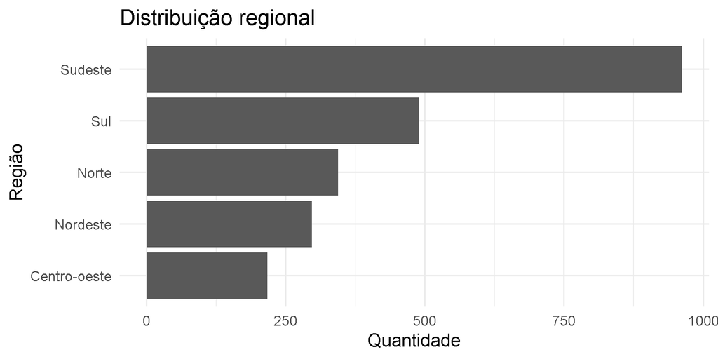

# **3. Estatística Descritiva**

## **Resumo estatístico do IMC**

| Média | Mediana | Desvio Padrão | Mínimo | Máximo |
| --- | --- | --- | --- | --- |
| 25.34 | 24.52 | 5.05 | 13.65 | 49.95 |

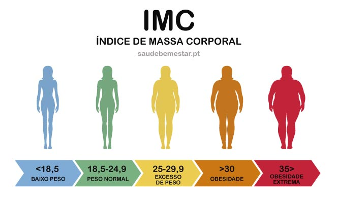

## **Distribuição do IMC**

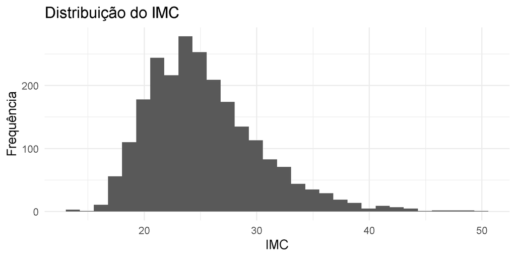

Interpretação:

- presença de dispersão moderada;
- possíveis outliers;
- leve assimetria;
- indícios de não normalidade.

## **QQ-Plot do IMC**

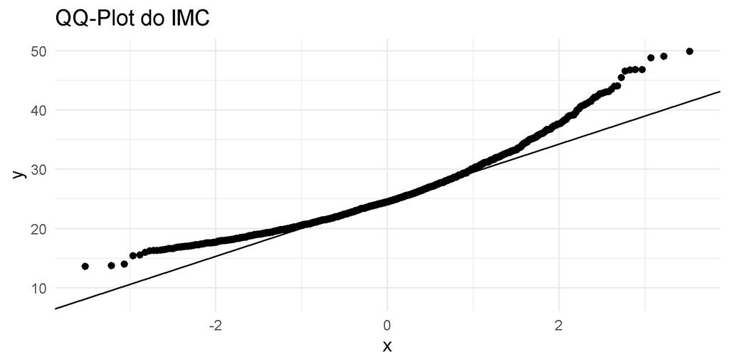

Interpretação:

- desvios da reta indicam não aderência à normalidade;
- presença de assimetria ou caudas discrepantes.

## **IMC segundo gênero**

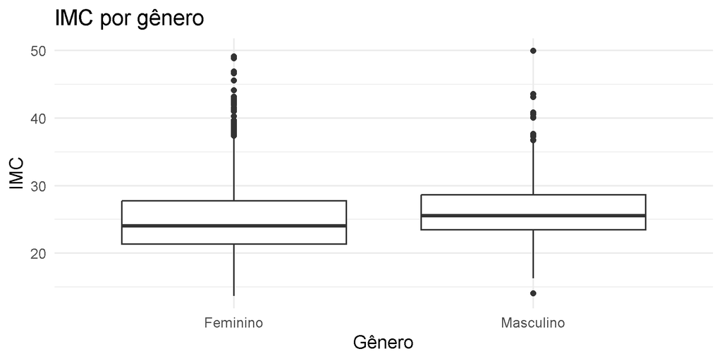

## **Distribuição etária**

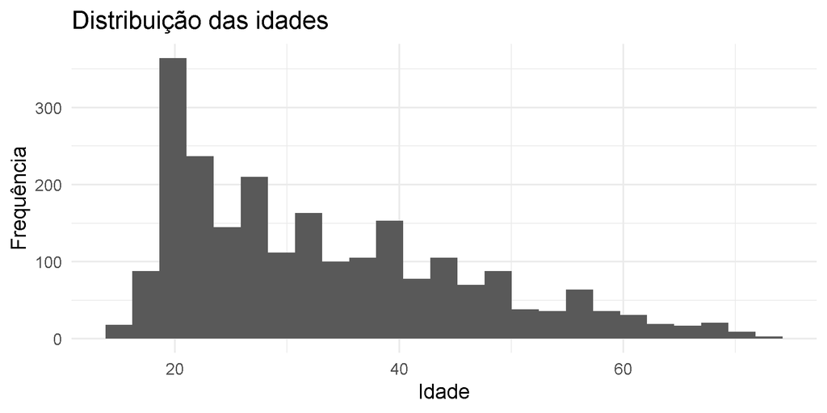

## **Mudança no delivery**

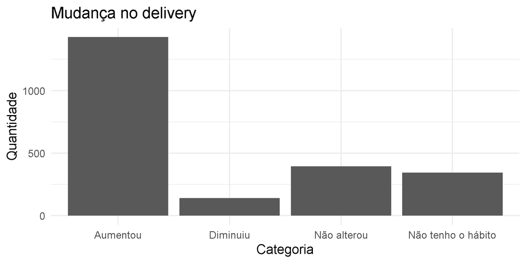

# **4. Análises Inferenciais**

## **Teste de Shapiro-Wilk**

Hipóteses:

$$H_0:\text{ normalidade}$$

$$H_1:\text{ não normalidade}$$

| Estatística | p-valor |
| --- | --- |
| 0.9585 | 0 |

Conclusão:

- rejeição da hipótese de normalidade;
- distribuição não aderente ao modelo normal;
- necessidade de cautela com métodos paramétricos.

## **Teste de Levene**

Hipóteses:

$$H_0:\sigma_1^2=\sigma_2^2=\cdots=\sigma_k^2$$

$$H_1:\text{ variâncias diferentes}$$

| df1 | df2 | statistic | p |
| --- | --- | --- | --- |
| 3 | 2306 | 9.91289 | 1.7e-06 |

Conclusão:

- se (p < 0.05), há heterocedasticidade;
- ANOVA clássica pode não ser adequada.

## **ANOVA de Welch**

Como houve indícios de heterocedasticidade, optou-se pela ANOVA de Welch, que é robusta à violação da homogeneidade das variâncias.

Hipóteses:

$$H_0:\mu_1=\mu_2=\cdots=\mu_k$$

$$H_1:\text{ pelo menos uma média difere}$$

| Estatística | p-valor |
| --- | --- |
| 5.1528 | 0.001556 |

Conclusão:

- diferenças significativas indicam associação entre IMC e atividade física.

## **IMC e atividade física**

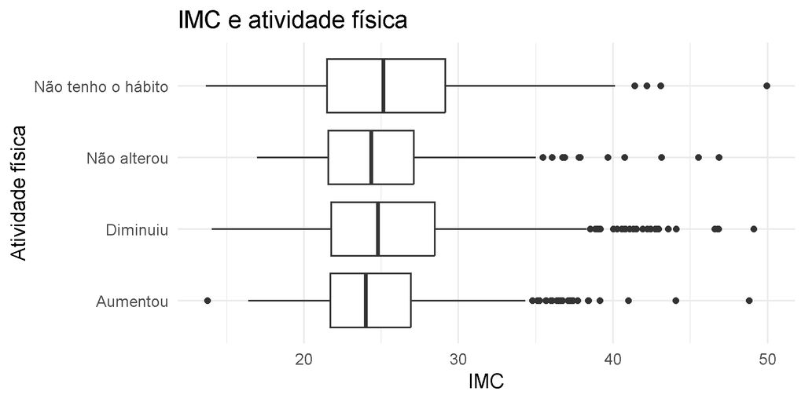

## **Teste Qui-Quadrado**

O teste Qui-Quadrado avalia associação entre variáveis qualitativas.

Hipóteses:

$$H_0:\text{ independência}$$

$$H_1:\text{ associação}$$

| Estatística | p-valor |
| --- | --- |
| 10.75 | 0.013156 |

Conclusão:

- associação sugere impacto da pandemia sobre o delivery.

## **Mapa de associação**

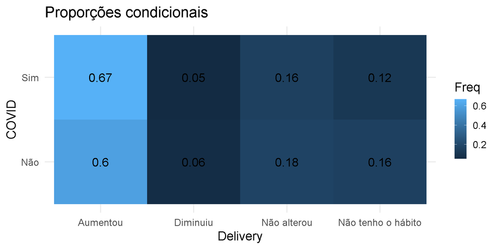

# **5. Correlação**

## **Correlação linear de Pearson**

O coeficiente de Pearson mede intensidade e direção da associação linear.

Hipóteses:

$$H_0:\rho=0$$

$$H_1:\rho\neq0$$

## **Matriz de correlação**

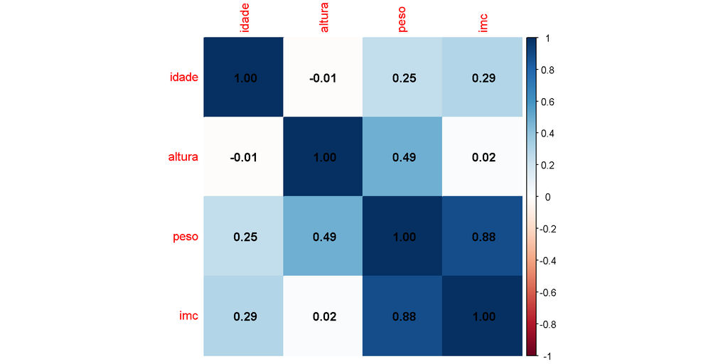

Interpretação:

- valores próximos de +1 indicam associação positiva;
- valores próximos de -1 indicam associação negativa;
- valores próximos de 0 indicam baixa relação linear.

## **Peso versus IMC**

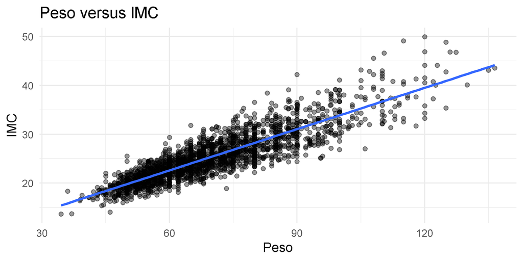

## **Síntese das correlações**

A análise indicou:

- forte associação entre peso e IMC;
- associação moderada entre altura e peso;
- baixa relação entre idade e variáveis corporais.

# **6. Conclusões**

## **Considerações finais**

A utilização de métodos descritivos e inferenciais permitiu:

- caracterização da amostra;
- comparação entre grupos;
- investigação de associações;
- interpretação quantitativa dos dados.

Limitações:

- dados autorreportados;
- possíveis vieses amostrais;
- ausência de acompanhamento longitudinal.

# **Referências**

Agresti, A. (2019)  
*An Introduction to Categorical Data Analysis.*

James, G. et al. (2021)  
*An Introduction to Statistical Learning.*

Johnson, R. A., & Wichern, D. W. (2007)  
*Applied Multivariate Statistical Analysis.*

Montgomery, D. C. (2019)  
*Design and Analysis of Experiments.*